# Bag of words tecnique to stablish sense of unity indicator into Oil and gas industry project

Viviane Schneider, PhD

09 de abril de 2020 - Last version: 23/09/2020

# 1 Context of study

# 2 Study goal

## 2.1 Research question

# 3 Methods, Materials and Techniques

## 3.1 Materials

**R Packages**

```r
# Pacotes e Funções
library(tidyverse) # Manipulacao eficiente de dados
library(tidytext) # Manipulacao eficiente de texto
library(textreadr) # Leitura de pdf para texto
library(tm) # Pacote de mineracao de texto com stopwords
library(wordcloud) # Grafico nuvem de palavras
library(igraph)
library(ggraph)
library(ggplot2)
library(dplyr)
library(pdftools)
library(RRPP)
```

## 3.2 Make a Corpus

```r
 txt <- system.file("texts", "txt", package = "tm")
(corpus <- VCorpus(DirSource("C:/Users/Jacob/Documents/Text Mining/storytelling", encoding = "UTF-8"),
 readerControl = list(language = "lat")))
```

```
## <<VCorpus>>
## Metadata:  corpus specific: 0, document level (indexed): 0
## Content:  documents: 9
```

## 3.3 Text Cleaning Function

```r
my_stops <- c("entrevistado", "fogaça", "que", "não", "tem", "uma", "ele", "você", "voce", "gente", "mas", "cara", "com", "por", "está", "esta", "isso", "vai", "então", "então", "pode", "assim", "acho", "uma", "coisa", "aqui", "ser", "ter", "sempre", "faz", "outro", "outra", "porque", "fazer", "tudo", "ali", "pra", "alguma", "vezes", "sim", "ver", "ser", "estar", "todo", "tipo", "da", "do", "feito", "fazer", "tal", "vou", "sei", "francisco", "fica", "dois", "dentro", "bom", "coisas", "felipe", "bem", "nesse", "caso", "menos", "questão", "falando", "dia", "dias", "algumas", "posso", "hoje", "falar", "vez", "exemplo", "quantas", "cada", "mundo", "acho", "cara", "entendi", "toda", "meio", "todos", "viu", "deu", "sendo", "podem", "caras", "pois", "vem", "outras", "algo", "desse", "nada", "nenhum", "naquele", "tanto", "vamos", "chegar", "sobre", "certo", "parte", "ainda", "parte", "bordo", "anos", "dizer", "aí", "ai", "é", "e", "né", "ne")

clean_corpus <- function(x){
  y <- tm_map(x, removePunctuation)
  x <- tm_map(y, content_transformer(tolower))
  x <- tm_map(x, removeNumbers)
  x <- tm_map(x, removeWords, words = c(stopwords("pt"), my_stops))
  x <- tm_map(x, stripWhitespace)
  return(x)
}

clean_corp <- clean_corpus(corpus)
```

# 4 Bag of word text mining techinique

## 4.1 Term Document Matrix (TDM)

the term-document matrix has terms in the first column and documents across the top as individual column names. The TDM is often the matrix used for language analysis. This is because you likely have more terms than authors or documents and life is generally easier when you have more rows than columns. An easy way to start analyzing the information is to change the matrix into a simple matrix using as.matrix() on the TDM.

```r
# Create a term-document matrix from the corpus
ST_tdm <- TermDocumentMatrix(clean_corp)

# Print coffee_tdm data
ST_tdm
```

```
## <<TermDocumentMatrix (terms: 7052, documents: 9)>>
## Non-/sparse entries: 14363/49105
## Sparsity           : 77%
## Maximal term length: 19
## Weighting          : term frequency (tf)
```

```r
# Convert to a matrix
ST_m <- as.matrix(ST_tdm)

# Print the dimensions of the matrix
dim(ST_m)
```

```
## [1] 7052    9
```

## 4.2 Document Term Matrix (DTM)

The document-term matrix is used when you want to have each document represented as a row. This can be useful if you are comparing authors within rows, or the data is arranged chronologically, and you want to preserve the time series. The tm package uses a “simple triplet matrix” class. However, it is often easier to manipulate and examine the object by re-classifying the DTM with as.matrix()

```r
# Create the document-term matrix from the corpus
ST_dtm <- DocumentTermMatrix(clean_corp)

# Print out coffee_dtm data
ST_dtm
```

```
## <<DocumentTermMatrix (documents: 9, terms: 7052)>>
## Non-/sparse entries: 14363/49105
## Sparsity           : 77%
## Maximal term length: 19
## Weighting          : term frequency (tf)
```

```r
# Convert coffee_dtm to a matrix
ST_m <- as.matrix (ST_dtm)

# Print the dimensions of coffee_m
dim(ST_m)
```

```
## [1]    9 7052
```

```r
# Review a portion of the matrix to get some Starbucks
```

# 5 Coherence of Sense of Unity

# 6 Context

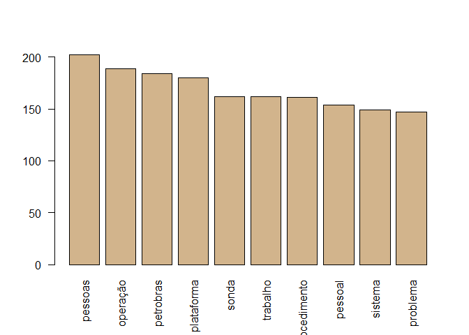

```r
library(qdap)

# Convert to a matrix
ST_m <- as.matrix(ST_tdm)

# Calculate the row sums
term_frequency <- rowSums(ST_m)

# Sort term_frequency in decreasing order
term_frequency <- sort(term_frequency, decreasing = TRUE)


# Plot a barchart of the 10 most common words
barplot(term_frequency[1:10], col = "tan", las = 2)
```

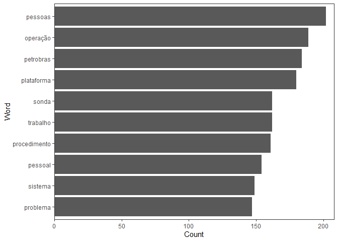

```r
# Create frequency
frequency <- freq_terms(
clean_corp,
top = 10,
at.least = 3,
stopwords("pt"))

plot(frequency)
```

```r
# Load wordcloud package
library(wordcloud)

# Print the first 10 entries in term_frequency

term_frequency[1:10]
```

```
##      pessoas     operação    petrobras   plataforma        sonda     trabalho
##          202          189          184          180          162          162
## procedimento      pessoal      sistema     problema
##          161          154          149          147
```

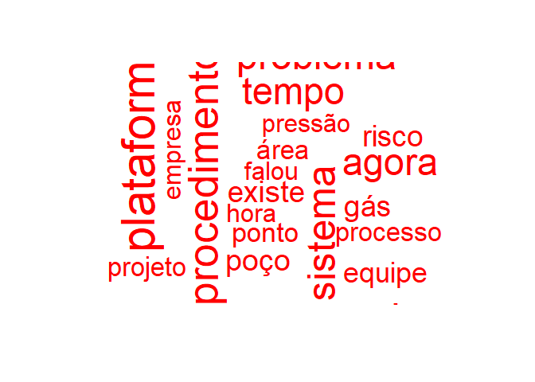

```r
# Vector of terms
terms_vec <-names(term_frequency)

# Create a word cloud for the values in word_freqs
wordcloud(terms_vec,term_frequency, max.words = 30, colors = "red")
```

Remove some words

```r
# Add to stopwords
stops <- c(stopwords(kind = 'pt'), 'ah', 'ahh', 'ahhh')

# Review last 6 stopwords
tail(stops)
```

```
## [1] "teria"    "teríamos" "teriam"   "ah"       "ahh"      "ahhh"
```

```r
# Apply to a corpus
cleaned_2_corp <- tm_map(clean_corp, removeWords,stops)
```

```r
library(viridisLite)
# Sort in descending order
sorted_corp_words <- sort(term_frequency, decreasing = TRUE)

# Print the 6 most frequent chardonnay terms
head(sorted_corp_words, 6)
```

```
##    pessoas   operação  petrobras plataforma      sonda   trabalho
##        202        189        184        180        162        162
```

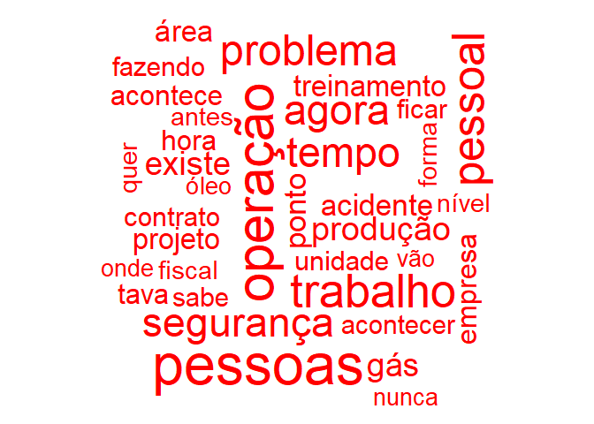

```r
# Get a terms vector
terms_vec <- names(term_frequency)

# Create a wordcloud for the values in word_freqs
wordcloud(terms_vec,term_frequency,
          max.words = 50, colors = "red")
```

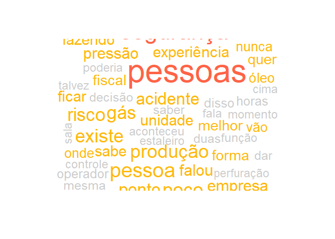

```r
# Print the word cloud with the specified colors
wordcloud(terms_vec,term_frequency,
    max.words = 80,
    colors = c("grey80", "darkgoldenrod1","tomato"))
```

```r
# Select 5 colors
color_pal <- cividis(n=5)

# Examine the palette output
color_pal
```

```
## [1] "#00204DFF" "#414D6BFF" "#7C7B78FF" "#BCAF6FFF" "#FFEA46FF"
```

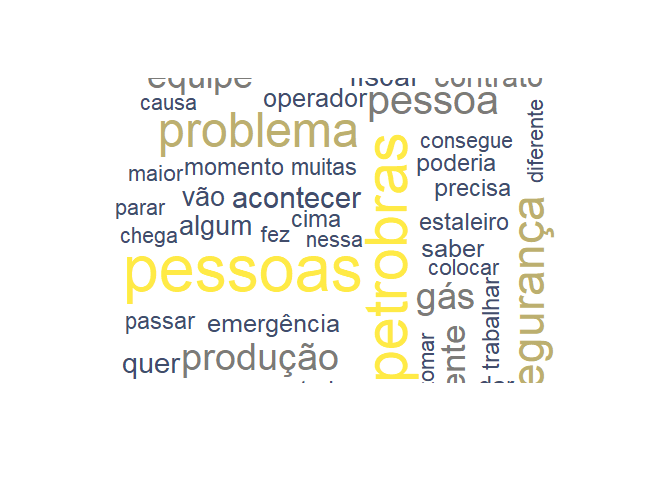

```r
# Create a word cloud with the selected palette
wordcloud(terms_vec,term_frequency,
          max.words = 100,
          colors = color_pal
          )
```

# 7 Common Words

## 7.1 Create one corpus

```r
 txt <- system.file("texts", "txt", package = "tm")
(corpus_m_o <- VCorpus(DirSource("C:/Users/Jacob/Documents/Text Mining/storytelling_m_o", encoding = "UTF-8"),
 readerControl = list(language = "lat")))
```

```
## <<VCorpus>>
## Metadata:  corpus specific: 0, document level (indexed): 0
## Content:  documents: 2
```

```r
clean_m_o <- clean_corpus(corpus_m_o)
```

## 7.2 Find common words

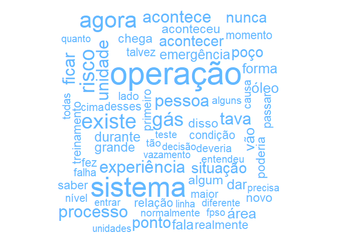

```r
O_M_tdm <- TermDocumentMatrix(clean_m_o)

O_M_m <- as.matrix(O_M_tdm)

# Print a commonality cloud
commonality.cloud(O_M_m, max.words = 100,colors = "steelblue1")
```

## 7.3 Visualize dissimilar words

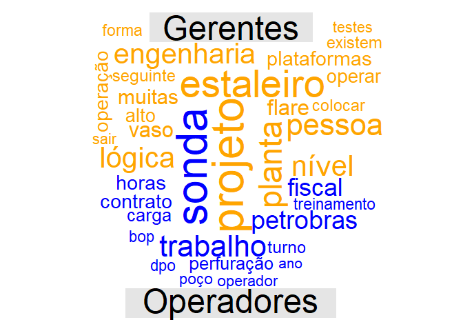

```r
# Give the columns distinct names
colnames(O_M_m) <- c("Gerentes", "Operadores")

# Create all_m
all_M_O <- as.matrix(O_M_m)

# Create comparison cloud
comparison.cloud(all_M_O,colors = c("orange", "blue"), max.words = 50)
```

## 7.4 Polarized tag cloud

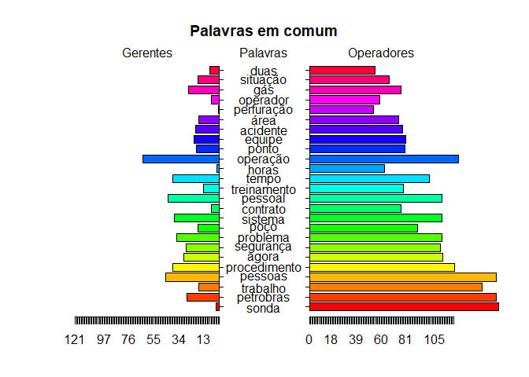

```
## 159 159
```

```
## [1] 5.1 4.1 4.1 2.1
```

```r
library(plotrix)
library(dplyr)

# Identify terms shared by both documents
common_words <- subset(all_M_O,
                       all_M_O[, 1] > 0 & all_M_O[, 2] > 0)
# Find most commonly shared words
difference <- abs(common_words[, 1] - common_words[, 2])
common_words <- cbind(common_words, difference)
common_words <- common_words[order(common_words[, 3],
decreasing = TRUE), ]

top25_df <- data.frame(
               Gerentes = common_words[1:25, 1],
               Operadores = common_words[1:25, 2],
               Palavras = rownames(common_words[1:25, ]))

pyramid.plot(top25_df$Gerentes, top25_df$Operadores,
  labels = top25_df$Palavras,
  top.labels = c("Gerentes", "Palavras", "Operadores"),
  main = "Palavras em comum",
  unit = NULL, raxlab = NULL,
  gap = 38 )
```

```r
Top200Words <- rownames(common_words[1:200, ])
```

## 7.5 Visualize word networks

```r
# Word association

stops_clouds <- rownames(common_words[20:nrow(common_words), ])

word_associate(content(clean_m_o[[1]]), match.string = "operação",
               stopwords = c(stops_clouds, my_stops, stopwords("pt")),
               network.plot = TRUE, cloud.colors = c("gray85", "darkred"))
```

```
##    row group unit                                                                                                                                                                                                                                                                                        …
## 1    5   all    5                        vaso antes flare exatamente separar líquido líquido voltar processo gás subir flare vaso topado chama cheio gás flare passou líquido rápido arrastou líquido cima durante procedimento despressurização gás passaria vaso passou vaso vaso cheio líquido passar …
## 2    8   all    8                                                                    acontece boas práticas engenharia delimitam muita feitas estaleiro realmente precisam feitas condição alto mar locação exigem poços produção interligados fluidos comissionar unidade rodar unidade acontece muitas …
## 3   12   all   12                                   operação disso relação intrinsecamente confiança confiança passa projeto confia participou confia equipe fez projeto confia operador tá operando unidade capacidade operar confia implementou todas lógicas garantem segurança plataforma feita imple…
## 4   17   all   17                    complicador forte seguinte unidade estaleiro especificamente fretamento construída empresa estaleiro qualquer fiscalizado empresa dona ativo equipe engenharia fiscalização supervisão realmente buscar receber conforme contratando serviço conforme adquirindo ati…
## 5   31   all   31 cultura tentando indústria petróleo acordou atrasado década segurança fechar empresa talvez industria aeronáutica indústrias acordando conceito integração áreas compõem empresa existe conflito objetivos próprio projeto construção comissionamento entrega grupo ótimo local equipe …
## 6   42   all   42                      agravante passar agora seguinte pessoal tá ligado prestando serviço contrato pendente pendência estaleiro passar realmente operação deve transição breve pessoal embora pequenos ajustes contratado dermos sorte estender contratato mesma equipe tá vir empresa p…
## 7   47   all   47            experiência necessário situação ocorra pessoa experiente passar algum treinamento capacidade analítica enxergar pessoa recémcontratada chega pouco tempo cargo certamente praticamente pôr mão fogo onde fala equipe operação fretada projeto desde inicio tá desde inicio p…
## 8   49   all   49                                           lado lado desde começo discutindo aprendendo errando sofrendo capacitação treinamento principalmente cargo liderança tomam decisões curso horas deixar capacitado vivência importante urucu onde passei tempo pegou desde começo urucu sabia …
## 9   53   all   53                                                                       faltou básica conseguiu evoluir enquanto tenta conseguiu empresa seguinte área chaves centro pesquisa rapaz trabalhou tempo reservatório projeto equipe prérequisito passar linha frente passar operação sentir d…
## 10  60   all   60                                                                                                          acham talvez procedimentos talvez formas diferentes treinamento conduzissem pessoa treinar cenários talvez talvez forma pensar diferente talvez maneira tradicional adequada v…
## 11  61   all   61            imagino discutido treinamentos ferramenta adequaria prepararia melhor gestor colega falou alguns treinamentos caixa diferentes senac rio janeiro treinamento emergência alguns simuladores alguns simuladores aceleram processo experiência desses fiz assumindo função gere…
## 12  66   all   66                                                                                                 voltando existem check list supervisor produção pessoal operação linha frente talvez evitasse acontecimento quitação pt especificamente válvula manual causa base bomba manual sido che…
## 13  81   all   81        feita ferramenta petrobras depender procedimento automatizalo existem certos níveis procedimento tão simples dominados escrever lógica descarrega operação fazendo procedimentos manuais possam gerar erros menores procedimento abrir válvula x acontece tá procedimento criar …
## 14  89   all   89        determinado momento manhã comentaram talvez libra plataformas pronta entrar operação produzir mil barris veem algum indicador talvez algum problema grave venha ocorrer quitando lista pendências pendências abertas viabilizar primeiro óleo fechados acelerar processo mil ram…
```

[output cut: 18 more lines]

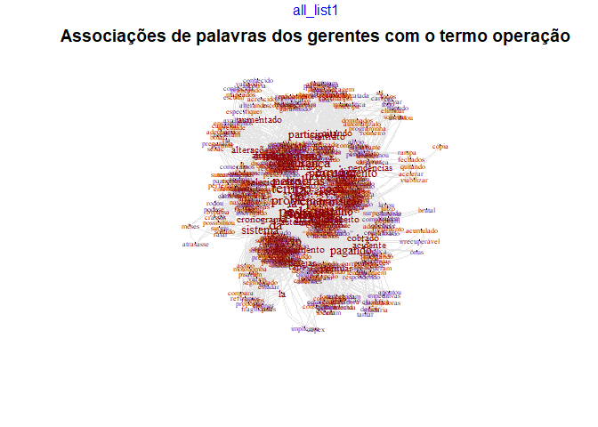

```r
title(main = "Associações de palavras dos gerentes com o termo operação")
```

# 8 Distance matrix and dendrogram

# 9 Make a dendrogram friendly TDM

```r
n_w <- 200

stops_corpus <- rownames(common_words[n_w:nrow(common_words), ])

common_corpus <- tm_map(clean_corp, removeWords,
                        words = c(stopwords("pt"), my_stops, stops_corpus))

tdm <- TermDocumentMatrix(common_corpus)

# Create tdm1
tdm1 <- removeSparseTerms(ST_tdm,sparse = 0.95)

# Create tdm2
tdm2 <- removeSparseTerms(ST_tdm, sparse = 0.975)

# Print tdm1
tdm1
```

```
## <<TermDocumentMatrix (terms: 7052, documents: 9)>>
## Non-/sparse entries: 14363/49105
## Sparsity           : 77%
## Maximal term length: 19
## Weighting          : term frequency (tf)
```

```r
# Print tdm2
tdm2
```

```
## <<TermDocumentMatrix (terms: 7052, documents: 9)>>
## Non-/sparse entries: 14363/49105
## Sparsity           : 77%
## Maximal term length: 19
## Weighting          : term frequency (tf)
```

# 10 Put it all together: a text-based dendrogram

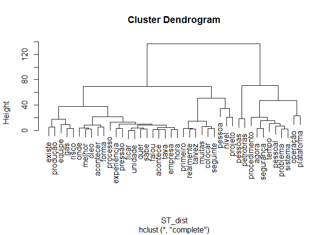

```r
common_wordsMO <- subset(all_M_O,
                       all_M_O[, 1] > 20 & all_M_O[, 2] > 20)


ST_dist <- dist(common_wordsMO)

# Create hc
hc <- hclust(ST_dist)

# Plot the dendrogram
plot(hc)
```

# 11 Dendrogram aesthetics

```r
library(dendextend)
```

```r
# Create hcd
hcd <- as.dendrogram(hc)

# Print the labels in hcd
labels(hcd)
```

```
##  [1] "existe"       "produção"     "equipe"       "gás"          "risco"
##  [6] "onde"         "melhor"       "óleo"         "acontecer"    "forma"
## [11] "processo"     "experiência"  "pressão"      "ficar"        "unidade"
## [16] "quer"         "sabe"         "falou"        "acontece"     "tava"
## [21] "empresa"      "hora"         "primeiro"     "realmente"    "talvez"
## [26] "muitas"       "colocar"      "seguinte"     "pessoa"       "nível"
## [31] "projeto"      "pessoas"      "petrobras"    "procedimento" "agora"
## [36] "segurança"    "tempo"        "pessoal"      "problema"     "sistema"
## [41] "operação"     "plataforma"
```

```r
# Change the branch color to red for "marvin" and "gaye"
hcd_colored <- branches_attr_by_labels(hcd,c("problema", "sonda"), color = "red")
```

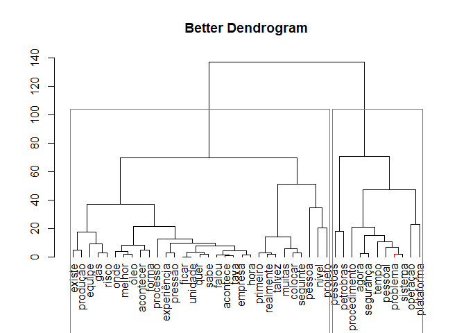

```r
# Plot hcd_colored
plot(hcd_colored, main = "Better Dendrogram")

# Add cluster rectangles
rect.dendrogram(hcd_colored,k = 2,border = "grey50")
```

# 12 Using word association

```r
library(ggthemes)
n_w <- 30

stops_corpus <- rownames(common_words[n_w:nrow(common_words), ])

common_corpus <- tm_map(clean_corp, removeWords,
                        words = c(stopwords("pt"), my_stops, stops_corpus))
tdm <- TermDocumentMatrix(common_corpus)


# Create associations
associations <- findAssocs(tdm,"problema",0.2)

# View the venti associations
associations
```

[output not shown]

[output cut: 1158 more lines]

[output not shown]

```r
# Create associations_df
associations_df <- list_vect2df(associations,col2 = "Palavra",col3 = "score")

associations_df <- arrange(associations_df, score)

associations_df[1:30,1:3]
```

```
##          X1      Palavra score
## 1  problema       chegam  0.20
## 2  problema      daquele  0.20
## 3  problema       abaixo  0.21
## 4  problema        carga  0.21
## 5  problema      contato  0.21
## 6  problema        falam  0.21
## 7  problema   inventário  0.21
## 8  problema        lance  0.21
## 9  problema       marina  0.21
## 10 problema     serviços  0.21
## 11 problema     abalroou  0.22
## 12 problema     abordado  0.22
## 13 problema absurdamente  0.22
## 14 problema     acertivo  0.22
```

[output cut: 16 more lines]

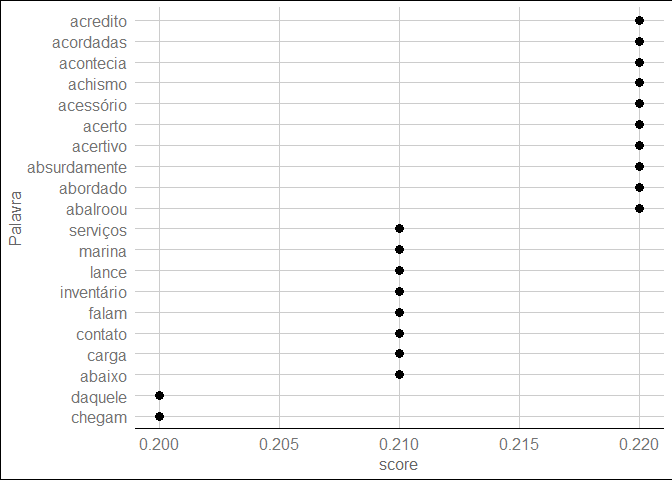

```r
# Plot the associations_df values
ggplot(associations_df[1:20,1:3], aes(score, Palavra)) +
  geom_point(size = 3) +
  theme_gdocs()
```

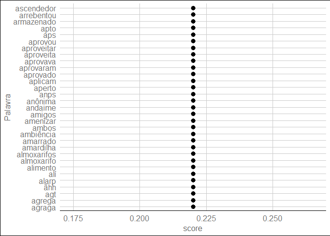

```r
# Plot the associations_df values
ggplot(associations_df[40:70,1:3], aes(score, Palavra)) +
  geom_point(size = 3) +
  theme_gdocs()
```

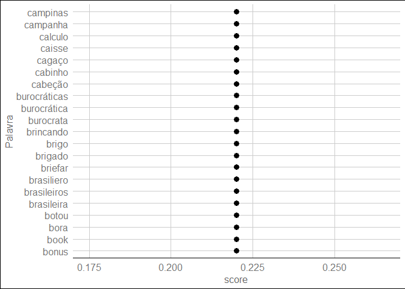

```r
ggplot(associations_df[110:130,1:3], aes(score, Palavra)) +
  geom_point(size = 3) +
  theme_gdocs()
```

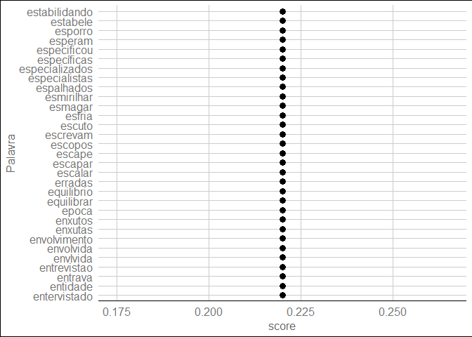

```r
ggplot(associations_df[300:330,1:3], aes(score, Palavra)) +
  geom_point(size = 3) +
  theme_gdocs()
```

# 13 N-gram tokenization

## 13.1 Changing n-grams

```r
library(RWeka)
# Make tokenizer function
tokenizer <- function(x) {
  NGramTokenizer(x, Weka_control(min = 2, max = 2))
}

# Create unigram_dtm
unigram_dtm <- DocumentTermMatrix(common_corpus)

# Create bigram_dtm
bigram_dtm <- DocumentTermMatrix(common_corpus,
  control = list(tokenize = tokenizer)
  )

# Print unigram_dtm
unigram_dtm
```

```
## <<DocumentTermMatrix (documents: 9, terms: 5239)>>
## Non-/sparse entries: 6820/40331
## Sparsity           : 86%
## Maximal term length: 19
## Weighting          : term frequency (tf)
```

```r
# Print bigram_dtm
bigram_dtm
```

```
## <<DocumentTermMatrix (documents: 9, terms: 11083)>>
## Non-/sparse entries: 11553/88194
## Sparsity           : 88%
## Maximal term length: 31
## Weighting          : term frequency (tf)
```

# 14 How do bigrams affect word clouds?

```r
# Create bigram_dtm_m
bigram_dtm_m <- as.matrix(bigram_dtm)

# Create freq
freq <- colSums(bigram_dtm_m)

# Create bi_words
bi_words <- names(freq)

# Examine part of bi_words
str_subset(bi_words,"^sonda")
```

```
##   [1] "sonda abalroamento"   "sonda acidente"       "sonda áfrica"
##   [4] "sonda afundou"        "sonda apaga"          "sonda auditoria"
##   [7] "sonda avaliam"        "sonda avisar"         "sonda balanço"
##  [10] "sonda besteira"       "sonda bonita"         "sonda botei"
##  [13] "sonda brasil"         "sonda cerca"          "sonda cobrar"
##  [16] "sonda cobrindo"       "sonda colaborador"    "sonda coletar"
##  [19] "sonda colhendo"       "sonda comoção"        "sonda compassada"
##  [22] "sonda comporta"       "sonda conseguiram"    "sonda contrato"
##  [25] "sonda cuida"          "sonda cuidar"         "sonda dá"
##  [28] "sonda degradado"      "sonda degradou"       "sonda derivar"
##  [31] "sonda diivulgado"     "sonda dinâmica"       "sonda dividido"
##  [34] "sonda dp"             "sonda dpo"            "sonda dryoff"
##  [37] "sonda duas"           "sonda efetiva"        "sonda eletrecista"
##  [40] "sonda eletrecistas"   "sonda elimina"        "sonda embarques"
##  [43] "sonda equipe"         "sonda especial"       "sonda estagiávamos"
```

[output cut: 23 more lines]

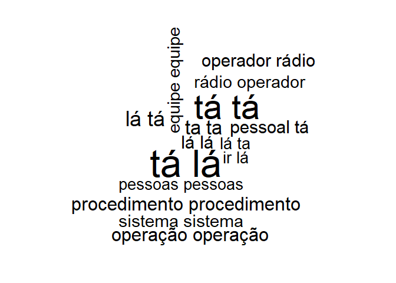

```r
# Plot a word cloud
wordcloud(bi_words,freq,max.words = 15)
```

# 15 Different frequency criteria

## 15.1 Changing frequency weights

.

```r
# Create a TDM
tdm <- TermDocumentMatrix(corpus_m_o)

# Convert it to a matrix
tdm_m <- as.matrix(tdm)

# Examine part of the matrix
tdm_m[c("problema")]
```

```
## [1] NA
```

```r
# Edit the controls to use Tfidf weighting
tdm <- TermDocumentMatrix(corpus_m_o,
       control = list(weighting = weightTfIdf))

# Convert to matrix again
tdm_m <- as.matrix(tdm)

# Examine the same part: how has it changed?
tdm_m[c("problema")]
```

```
## [1] NA
```

# 16 Capturing metadata in tm

```r
# Examine the first doc content
content(corpus_m_o[[1]])
```

```
##   [1] "            TRANSCRIÇÃO ENTREVISTA SANTOS 19/09"
##   [2] "Produção – Grupo fiscais Libra"
##   [3] ""
##   [4] "- Então o caso relatado por você do acidente que aconteceu de forma fictícia foi uma perda de controle do nível do vaso de flor durante o procedimento de comissionamento, a partida das bombas do vaso flare foi colocada em modo manual, o sistema de intertravamento do alarme de alto que part…
##   [5] "O vaso antes do flare é para exatamente separar o líquido, o líquido voltar para o processo e só o gás subir para o flare e como o vaso estava topado como a gente chama, estava cheio, o gás para chegar no flare passou pelo líquido muito rápido e arrastou o líquido para cima, mas isso duran…
##   [6] "Em diversas ocasiões é uma ação a favor da segurança, nesse caso em específico é o contrário, vai contra a segurança, agora eu lembrei que vocês comentaram, foi feita uma despressurização, mas foi feito sem saber que o nível estava acima... sem associar o problema que já estava acontecendo…
##   [7] "É uma questão de limitação então, não é por que é negligenciado, assim como existem testes que são bem-vindos que aconteçam durante o estaleiro porque a condição da FPSO está docado, é a favor desse teste acontecer, existem outros que só acontecem na locação, em relação a parte de intertra…
##   [8] "O que acontece é que assim, as boas práticas de engenharia delimitam bem muita coisa que são para ser feitas em estaleiro e outras coisas que realmente precisam ser feitas na condição de alto mar, da locação, porque exigem que os poços de produção estejam interligados para que a gente tenh…
##   [9] "Nós temos a lista de aceitação para unidade, tem a sociedade classificadora que permite, mas ela não chega nesse nível de detalhe."
##  [10] "O detalhe da lógica em si, você tem que acompanhar a implementação da matriz de causa - efeito e fazer testes, por exemplo, na área submarina da plataforma que é uma responsabilidade da Petrobras, o equipamento é nosso, o domínio é nosso, quando a gente afreta uma plataforma, a parte de pr…
##  [11] "Em unidades próprias, a Petrobras deve fazer isso e vai fazer isso de uma forma mais intrusiva porque o processo é nosso e tem um departamento de automação que se sente responsável por isso, porque dá um problema vai cair no CPF do cara, então a Petrobras com certeza tem um olho muito mais…
##  [12] "A operação disso é uma relação intrinsecamente de confiança e essa confiança passa de um projeto que você confia ou porque você mesmo participou, porque você confia na equipe que fez o projeto de que ele foi bem feito, que você confia que o operador que tá operando a unidade tem capacidade…
##  [13] "A gente não pode esquecer também que apesar de ser fretada, ela também interesse também que tudo esteja correto, o equipamento é dela, porque é um ativo dela, é a fonte de que ela vai conseguir se capitalizar, um investimento todo feito, então ela tem interesse em fazer isso, que a gente n…
##  [14] "Então quando a gente vê o pessoal lá relevando esse tipo de coisa, o cara tem que sentir que é ele que tá ali também, então essa cultura de que aquilo não é banal, que aquilo pode tirar a vida dele e de várias pessoas, então isso é uma conscientização pesada que tem que estar sempre reflet…
##  [15] "O nível de supervisão que você perguntou só acontece em uma etapa de comissionamento bem realizada, porque você tem que questionar o que está implementado, pode existir uma falha, toda falha é humana, então seja, ele pode ter feito o melhor trabalho que ele pode, mas ele esqueceu, por exem…
```

[output cut: 256 more lines]

```r
# Access the first doc metadata
meta(corpus_m_o[1])
```

```
## data frame with 0 columns and 1 row
```

# 17 Step 1 - Define the problem and question

# 18 Step 2: Identifying the text sources

# 19 Step 3: Text organization

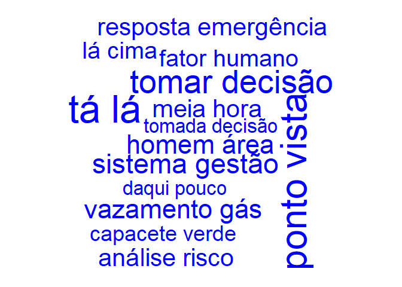

```r
tokenizer <- function(x)
  NGramTokenizer(x, Weka_control(min = 2, max = 2))

clean_m_o <- clean_corpus(corpus_m_o)

# Create amzn_p_tdm
m_o_p_tdm <- TermDocumentMatrix(clean_m_o,
control = list(tokenize = tokenizer)
 )

# Create amzn_p_tdm_m
m_o_p_tdm_m <- as.matrix(m_o_p_tdm)

# Create amzn_p_freq
m_o_p_freq <- rowSums(m_o_p_tdm_m)

# Plot a word cloud using amzn_p_freq values
wordcloud(names(m_o_p_freq),m_o_p_freq,max.words = 25, color = "blue" )
```

http://www.stat.columbia.edu/~tzheng/files/Rcolor.pdf

https://eight2late.wordpress.com/2015/05/27/a-gentle-introduction-to-text-mining-using-r/

https://cran.r-project.org/web/packages/corpus/vignettes/corpus.html

https://rpubs.com/malkoves/DS_project